# Files and Folders

## About this R Notebook

R Notebooks are a ‘flavor’ of R markdown that combine plain text with R commands in code chunks. You can (and should!) edit them, and save it every few minutes like anything else!

Minimize the console. You won’t need it because the output will appear below each code chunk.

To view a copy of your notebook as HTML, just hit Save, then Preview.

Useful keyboard shortcuts:

- run the current line of R: *ctrl + enter*
- run everything in the current code chunk: *ctrl + shift + enter*
- insert a new code chunk: *ctrl + alt + i*

## List Files in a Directory

View the working directory:

```r
getwd()
```

```
[1] "D:/Workshops/R-Spatial/rspatial_mod/outputs/rspatial_data"
```

List the files in the current working directory. Note ‘.’ is shorthand for the current working directory.

```r
list.files(".")
```

```
 [1] "data"                             "gadm36_ZMB_2_sp.rds"              "LICENSE"
 [4] "nb.bak"                           "nb.css"                           "nb_geop_01.nb.html"
 [7] "nb_geop_01.Rmd"                   "nb_geop_02.nb.html"               "nb_geop_02.Rmd"
[10] "nb_spatial-qry.nb.html"           "nb_spatial-qry.Rmd"               "nb01_syntax-review.nb.html"
[13] "nb01_syntax-review.Rmd"           "nb01_syntax-review_ans.nb.html"   "nb01_syntax-review_ans.Rmd"
[16] "nb02_files-folders.nb.html"       "nb02_files-folders.Rmd"           "nb02_files-folders_ans.nb.html"
[19] "nb02_files-folders_ans.Rmd"       "nb03a_tables101.nb.html"          "nb03a_tables101.Rmd"
[22] "nb03a_tables101_ans.nb.html"      "nb03a_tables101_ans.Rmd"          "nb03b_plotting101.nb.html"
[25] "nb03b_plotting101.Rmd"            "nb04_import-gis-data.nb.html"     "nb04_import-gis-data.Rmd"
[28] "nb04_import-gis-data_ans.nb.html" "nb04_import-gis-data_ans.Rmd"     "notebooks_2021-03-18.zip"
[31] "README.md"                        "scripts"                          "scripts.zip"
[34] "test_working_dir.R"               "ZMB_msk_alt.grd"                  "ZMB_msk_alt.gri"
[37] "ZMB_msk_alt.vrt"
```

**CHALLENGE**. List all the files in your ‘Home’ directory. (Hint: the shortcut for the Home directory is ‘~’) [Answer](http://bit.ly/38UPrbQ)

```r
## List files in your 'Home' directory
list.files("~")
```

```
 [1] "Adobe"                     "ArcGIS"                    "ArcGIS Pro 2.5"
 [4] "Audacity"                  "Backups"                   "Beahrs_ELP"
 [7] "Berkeley"                  "BMA"                       "Camtasia"
[10] "Citizenship"               "Consulting"                "Custom Office Templates"
[13] "Database1.accdb"           "Default.rdp"               "desktop.ini"
[16] "eMotion"                   "GIS DataBase"              "IGIS"
[19] "IGIS_BigFiles"             "Job Apps"                  "McAfee Vaults"
[22] "my-google-geocode-api.bak" "my-google-geocode-api.txt" "My Bookmarks"
[25] "My Clipart"                "My Data Sources"           "My Hardware"
[28] "My Keys"                   "My Music"                  "My Pictures"
[31] "My PowerPoint Collection"  "My Presentations"          "My Reference Library"
[34] "My Scripts"                "My Sounds"                 "My Spatial Data"
[37] "My Syllabi Collection"     "My Teaching"               "My Tech Library"
[40] "My Video Collection"       "My Videos"                 "my_random_numbers.RData"
[43] "NewBlueFX"                 "Notes and To Do Lists"     "Papers"
[46] "participants2_files"       "Personal"                  "pix4d"
[49] "Product Research"          "R"                         "Receipts"
[52] "Research"                  "Riverdale"                 "Scanned Documents"
[55] "Stanford"                  "tempFolderPath.dat"        "test.html"
[58] "test.Rmd"                  "UFL Works"                 "WebPages"
[61] "Workshops & Conferences"   "Zilo"                      "Zoom"
```

List the Shapefiles in the ‘data’ directory.

```r
list.files("./data", pattern = "*.shp")
```

```
[1] "sf_schools.shp"    "veg37.shp"         "veg37.shp.xml"     "yose_boundary.shp" "yose_poi.shp"
[6] "yose_poi.shp.xml"
```

## Verify a File Exists

Write an expression that will check if a file named “sf_libraries.csv” exists in the data directory.

```r
file.exists("./data/sf_libraries.csv")
```

```
[1] TRUE
```

## Import a CSV File

Import the *sf_libraries.csv* file.

```r
my_data <- read.csv("./data/sf_libraries.csv")

# View(my_data)
```

**CHALLENGE**: What type of R object does `read.csv()` return?

```r
class(my_data)
```

```
[1] "data.frame"
```

## Saving R Objects to Disk

Any R object can be saved to disk in a special native R format, which you can load back into R.

Create 1000 random values using the random number function of your choice (e.g., `rnorm()`).

```r
rnd_vals <- rnorm(1000) * 20
```

**CHALLENGE**: Create a histogram of the values.

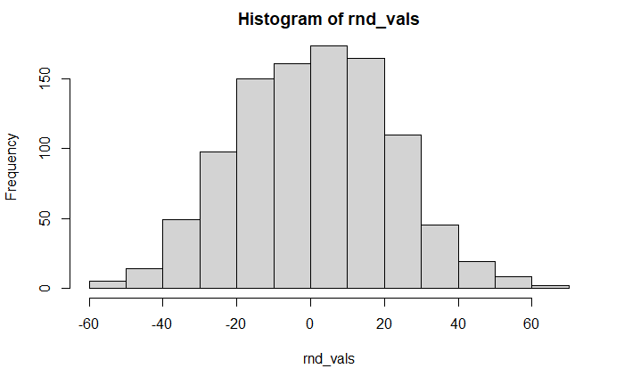

```r
hist(rnd_vals)
```

Save your random numbers to your ‘Home’ directory using `save()`:

```r
save(rnd_vals, file="~/my_random_numbers.RData")
```

## End

Congratulations, you have completed the Notebook!